# FRTCI: Systematic Variation Estimation Package Tutorial

Ding, P., Feller, A., and Miratrix, L.

2018-11-21

# Introduction

This document demonstrates how to use the systematic variation estimation methods of the `FRTCI` package. First load the package:

```r
library( FRTCI )
```

This package has code to make synthetic data. Here we make a dataset with 3 covariates that we will use to illustrate the function calls. For this dataset, the first two variables have a systematic relationship with treatment impact, and the third is good for adjustment for increasing power:

```r
df = make.randomized.dat( 100, gamma.vec=c(1,1,1,2), beta.vec=c(-1,-1,1) )
str( df )
```

```
## 'data.frame':    100 obs. of  8 variables:
##  $ A   : num  4.16 2.82 4.02 3.6 3.73 ...
##  $ B   : num  4.75 4.06 4.7 4.17 3.84 ...
##  $ C   : num  4.51 3.12 5.54 3.93 2.76 ...
##  $ Y.0 : num  20 13.3 19.3 14 14.8 ...
##  $ Y.1 : num  19.6 13.5 19 13.6 13.9 ...
##  $ tau : num  -0.403 0.242 -0.325 -0.426 -0.889 ...
##  $ Z   : num  0 0 1 1 0 1 1 0 0 1 ...
##  $ Yobs: num  20 13.3 19 13.6 14.8 ...
```

## Basic estimation

The function `est.beta` is our core estimator (the naive estimator):

```r
rs = est.beta( Yobs ~ Z,  interaction.formula = ~ A + B, data=df )
rs
```

```
## RI het tx regression (RI-Unadjusted):
##  est.beta(formula = Yobs ~ Z, data = df, interaction.formula = ~A +
##      B)
##
## Coefficients:
## (Intercept)            A            B
##    -17.3503      -0.2857       5.8569
##
## Var-Cor Matrix:
##             (Intercept)          A          B
## (Intercept)    93.42189 -16.077430 -16.009624
## A             -16.07743   8.571124  -3.089222
## B             -16.00962  -3.089222   8.647634
##
## Chi-squared test for systematic variation: X^2=4.40 ; p=0.111
##
## Details:  ATE = -0.410 +/- 1.234     SD( Y(0) ) = 2.914   SD( Y(1) ) = 3.323
```

The arguments are observed outcome, observed treatment assignment, and what variables to find a systematic relationship to, expressed as a formula using the tilde notation (categorical covariates will be automatically converted).

We can obtain our standard errors and variance-covariance matrix that comes from the design-based theory:

```r
vcov( rs )
```

```
##             (Intercept)          A          B
## (Intercept)    93.42189 -16.077430 -16.009624
## A             -16.07743   8.571124  -3.089222
## B             -16.00962  -3.089222   8.647634
```

```r
SE( rs )
```

```
## (Intercept)           A           B
##    9.665500    2.927648    2.940686
```

and confidence intervals (using the normal approximation)

```r
confint( rs )
```

```
##                    2.5 %    97.5 %
## (Intercept) -36.29428646  1.593776
## A            -6.02380704  5.452363
## B             0.09322184 11.620499
```

# OLS adjustment

OLS is basically using the emperical covariance matrix $\widehat{S}_{xx}$ (`Sxx.hat`) for each treatment arm rather than the known Sxx:

```r
M.ols.ours = est.beta( Yobs ~ Z, ~ A + B, data=df, method="OLS" )
M.ols.ours
```

```
## RI het tx regression (OLS-Unadjusted):
##  est.beta(formula = Yobs ~ Z, data = df, interaction.formula = ~A +
##      B, method = "OLS")
##
## Coefficients:
## (Intercept)            A            B
##      1.3872      -1.6685       0.8559
##
## Var-Cor Matrix:
##             (Intercept)           A           B
## (Intercept)   2.2373278 -0.31175188 -0.38746723
## A            -0.3117519  0.13767908 -0.03734967
## B            -0.3874672 -0.03734967  0.16904501
##
## Chi-squared test for systematic variation: X^2=21.24 ; p=0.000
##
## Details:  ATE = -0.410 +/- 1.234     SD( Y(0) ) = 2.914   SD( Y(1) ) = 3.323
```

```r
M.ols.ours$beta.hat
```

```
## (Intercept)           A           B
##   1.3871632  -1.6684590   0.8558602
```

Simple interaction-based OLS approach, as a comparison:

```r
M0 = lm( Yobs ~ (A+B) * Z, data=df )
M0
```

```
##
## Call:
## lm(formula = Yobs ~ (A + B) * Z, data = df)
##
## Coefficients:
## (Intercept)            A            B            Z          A:Z
##      2.1466       2.1646       1.4888       1.3872      -1.6685
##         B:Z
##      0.8559
```

```r
M.ols.ours$beta - coef(M0)[4:6]
```

```
##   (Intercept)             A             B
## -8.859580e-14  8.437695e-15 -2.331468e-15
```

There are no differences up to machine precision.

# Model adjustment

The model-adjusted estimator automatically is used if you give two formula, one for the treatment model, one for the control adjustment model

```r
est.beta( Yobs ~ Z, interaction.formula = ~ A + B,
          control.formula = ~ C, data=df )
```

```
## RI het tx regression (RI-Adjusted):
##  est.beta(formula = Yobs ~ Z, data = df, interaction.formula = ~A +
##      B, control.formula = ~C)
##
## Coefficients:
## (Intercept)            A            B
##    -14.8456      -0.8218       5.4842
##
## Var-Cor Matrix:
##             (Intercept)          A          B
## (Intercept)    70.06356 -11.006505 -12.615601
## A             -11.00651   7.447868  -3.800551
## B             -12.61560  -3.800551   8.125463
##
## Chi-squared test for systematic variation: X^2=4.24 ; p=0.120
##
## Details:  ATE = -0.410 +/- 1.234     SD( Y(0) ) = 2.914   SD( Y(1) ) = 3.323
```

# Model adjustment + OLS adjustment

using adjustment: we can do with and without emperical Sxx.

```r
est.beta( Yobs ~ Z,  ~ A + B, ~ C, data=df )$beta.hat
```

```
## (Intercept)           A           B
## -14.8455625  -0.8218424   5.4842380
```

```r
rs = est.beta( Yobs ~ Z,  ~ A + B, ~ C, data=df, empirical.Sxx = TRUE )
rs$beta.hat
```

```
## (Intercept)           A           B
##   4.7032083  -2.2389466   0.2188013
```

same as model-adjustment + empirical.Sxx, above

```r
rs2 = est.beta( Yobs ~ Z,  ~ A + B, ~ C, data=df, method="OLS" )
rs2$beta.hat
```

```
## (Intercept)           A           B
##   4.7032083  -2.2389466   0.2188013
```

# Oracle estimator (for simulations and verification of formulae)

If we know all potential outcomes, we can calculate the exact beta for the sample. (This is useful for simulation studies.) We can also get the true SE, which is why we pass a sample treatment vector (so it can calculate proportion treated, under the assumption of simple random assignment):

```r
Moracle = calc.beta.oracle( Y.1 + Y.0 ~ Z, ~ A + B, data=df )
Moracle
```

```
## RI het tx regression (Oracle RI):
##  calc.beta.oracle(formula = Y.1 + Y.0 ~ Z, data = df, interaction.formula = ~A +
##      B)
##
## Coefficients:
## (Intercept)            A            B
##          -1           -1            1
##
## Var-Cor Matrix:
##             (Intercept)          A         B
## (Intercept)   102.07865 -15.331801 -19.64688
## A             -15.33180   8.449954  -3.24067
## B             -19.64688  -3.240670  10.03566
##
## Chi-squared test for systematic variation: X^2=NA ; p=NA
```

```r
SE( Moracle )
```

```
## (Intercept)           A           B
##   10.103398    2.906880    3.167911
```

It will give the same results regardless of $Z$ assuming the total number of units remains the same.

# When there is no het tx variation

Here we see all the methods on a scenario with no variation

```r
df = make.randomized.dat( 1000, beta.vec=c(-1,0,0) )

calc.beta.oracle( Y.1 + Y.0 ~ Z, ~ A + B, data=df )$beta.hat
```

```
##   (Intercept)             A             B
## -1.000000e+00 -1.278977e-13  1.421085e-13
```

```r
est.beta( Yobs ~ Z, ~ A + B, data=df )$beta.hat
```

```
## (Intercept)           A           B
##   2.1876075  -2.0268431   0.8938081
```

```r
est.beta( Yobs ~ Z, ~ A + B, data=df, method="OLS" )$beta.hat
```

```
## (Intercept)           A           B
## -0.69066825 -0.12080443  0.01971511
```

# Looking at $R^2$

We can look at treatment effect explained. We will look at two scenarios, one with no ideosyncratic variation, and one with a substantial amount. We will plot the R2 sensitivity curves for each on top of each other.

```r
df = make.randomized.dat( 1000, beta.vec=c(-1,1,1) )
rs = est.beta( Yobs ~ Z, ~ A + B, data=df, method="OLS" )
r2 = R2.ITT( rs )
r2
```

```
## Heterogenous Tx Effect R^2 (ITT)
##  R^2:             0.298 | 0.457 -- 0.997
##
##   Treatment Effect Variances:
##  Systematic:  2.750
##  Ideosyncratic:   0.009 -- 3.273 | 6.473
##  Total:   2.760 -- 6.023 | 9.223
```

```r
plot( r2 )
df = make.randomized.dat( 1000, beta.vec=c(-1,1,1), ideo.sd=3 )
rs = est.beta( Yobs ~ Z, ~ A + B, data=df, method="OLS" )
r2 = R2.ITT( rs )
r2
```

```
## Heterogenous Tx Effect R^2 (ITT)
##  R^2:             0.143 | 0.217 -- 0.457
##
##   Treatment Effect Variances:
##  Systematic:  3.616
##  Ideosyncratic:   4.302 -- 13.063 | 21.649
##  Total:   7.919 -- 16.680 | 25.265
```

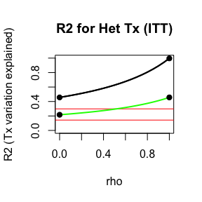

```r
plot( r2, ADD=TRUE, col="green" )
```

And here is a case where we have 100% systematic variation along a single variable.

```r
df = make.randomized.dat( 1000, beta.vec=c(-1,1,0) )
rs = est.beta( Yobs ~ Z, ~ A + B, data=df, method="OLS" )
r2 = R2.ITT( rs )
r2
```

```
## Heterogenous Tx Effect R^2 (ITT)
##  R^2:             0.108 | 0.194 -- 0.983
##
##   Treatment Effect Variances:
##  Systematic:  0.849
##  Ideosyncratic:   0.015 -- 3.536 | 6.990
##  Total:   0.863 -- 4.384 | 7.838
```

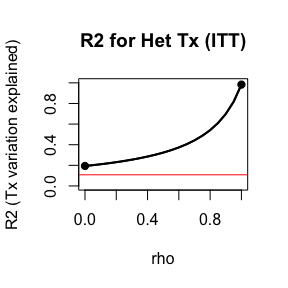

```r
plot( r2 )
```

See, we have 100% R2, if we knew the true individual treatment effects:

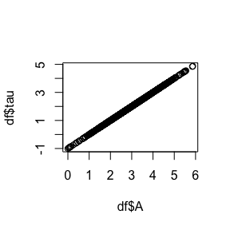

```r
plot( df$tau ~ df$A )
```

## Comparing estimators

Here we look at how results differ across different estimators

```r
df = make.randomized.dat( 1000, beta.vec=c(-1,1,1), ideo.sd=1 )

rs = est.beta( Yobs ~ Z, ~ A + B, data=df )
r2 = R2.ITT( rs )
r2
```

```
## Heterogenous Tx Effect R^2 (ITT)
##  R^2:             0.101 | 0.181 -- 0.873
##
##   Treatment Effect Variances:
##  Systematic:  1.131
##  Ideosyncratic:   0.164 -- 5.114 | 10.116
##  Total:   1.295 -- 6.245 | 11.247
```

```r
plot( r2, col="green" )

# adjusted
rs = est.beta( Yobs ~ Z, ~ A + B, ~ C, data=df )
r2 = R2.ITT( rs )
r2
```

```
## Heterogenous Tx Effect R^2 (ITT)
##  R^2:             0.309 | 0.467 -- 0.973
##
##   Treatment Effect Variances:
##  Systematic:  4.110
##  Ideosyncratic:   0.114 -- 4.694 | 9.196
##  Total:   4.224 -- 8.804 | 13.307
```

```r
plot( r2, ADD=TRUE )

# adjusted + OLS
rs = est.beta( Yobs ~ Z, ~ A + B, ~ C, data=df, empirical.Sxx = TRUE )
r2 = R2.ITT( rs )
r2
```

```
## Heterogenous Tx Effect R^2 (ITT)
##  R^2:             0.434 | 0.605 -- 0.971
##
##   Treatment Effect Variances:
##  Systematic:  7.832
##  Ideosyncratic:   0.233 -- 5.113 | 10.198
##  Total:   8.065 -- 12.945 | 18.030
```

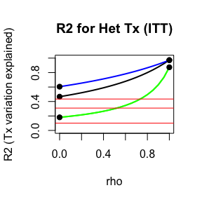

```r
plot( r2, ADD=TRUE, col="blue" )
```

# Testing LATE estimators

Our estimators also work in non-compliance contexts (see paper for details). The story is analogous to the code above.

For this illustration we generate some fake data using a provided function included with the package. It takes a complier treatment heterogeniety model defined by `beta`:

```r
beta = c(-1,6,0)
n = 1000

data = make.randomized.compliance.dat( n, beta.vec=beta )
names(data)
```

```
##  [1] "A"    "B"    "C"    "Y.0"  "Y.1"  "tau"  "Z"    "Yobs" "S"    "D"
```

```r
head( data )
```

```
##          A        B        C      Y.0      Y.1      tau Z     Yobs  S D
## 1 3.045145 3.996099 2.829962 17.01679 17.01679  0.00000 1 17.01679 AT 1
## 2 2.591728 3.074410 3.043920 17.64179 32.19215 14.55037 1 32.19215  C 1
## 3 3.353971 3.371702 3.077184 17.39482 36.51865 19.12383 0 17.39482  C 0
## 4 4.212972 2.773202 5.020846 19.10203 43.37986 24.27783 0 19.10203  C 0
## 5 3.518684 5.461010 4.228731 23.33157 23.33157  0.00000 1 23.33157 AT 1
## 6 4.076051 3.339851 2.963390 17.99283 41.44914 23.45631 1 41.44914  C 1
```

```r
zd = with( data, interaction( Z, D, sep="-" ) )
```

Our four observable groups defined by treatment assignment and take-up are as follows:

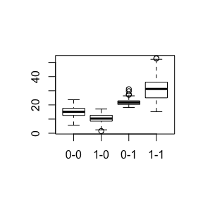

```r
boxplot( Yobs ~ zd, data=data )
```

The true relationships for the three latent groups are as follows:

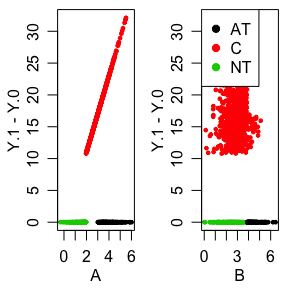

```r
par( mfrow=c(1,2), mgp=c(1.8,0.8,0), mar=c(3,3,0.5,0.5) )
plot( Y.1 - Y.0 ~ A, data=data, col=as.factor(data$S), pch=19, cex=0.5 )
plot( Y.1 - Y.0 ~ B, data=data, col=as.factor(data$S), pch=19, cex=0.5 )
legend( "topleft", legend=levels( as.factor( data$S ) ), pch=19, col=1:3 )
```

(We see no impacts for the AT and the NT as required under the assumptions of noncompliance here.)

## Estimating the effects

```r
rs = est.beta.LATE( Yobs ~ D | Z, ~ A + B, data=data )
rs
```

```
## RI het tx regression (LATE RI-RI):
##  est.beta.LATE(formula = Yobs ~ D | Z, data = data, interaction.formula = ~A +
##      B)
##
## Coefficients:
## (Intercept)            A            B
##      -6.533        6.889        1.076
##
## Var-Cor Matrix:
##             (Intercept)          A          B
## (Intercept)   160.09058 -28.064301 -29.060274
## A             -28.06430   5.524569   4.390154
## B             -29.06027   4.390154   6.114327
##
## Chi-squared test for systematic variation: X^2=15.96 ; p=0.000
```

```r
rs$beta.hat
```

```
## (Intercept)           A           B
##   -6.532515    6.889152    1.075725
```

```r
SE( rs )
```

```
## (Intercept)           A           B
##   12.652691    2.350440    2.472717
```

```r
# error
rs$beta.hat - beta
```

```
## (Intercept)           A           B
##  -5.5325151   0.8891521   1.0757245
```

```r
r2 = R2.LATE( rs )
r2
```

```
## Heterogenous Tx Effect R^2 (LATE)
##  R^2 (within Compliers):      0.397 | 0.470 -- 0.610
##  R^2 for noncompliance alone:     0.613 | 0.653 -- 0.709
##  R^2 for covariates & compliance: 0.767 | 0.816 -- 0.886
##
##   Variances:
##  Systematic Tx Var (Compliers):   23.230
##  Systematic Tx Var (Strata):  63.988
##  Total Systematic Var:        80.017
##  Ideosyncratic Tx Var (Comp):     14.882 -- 26.157 | 35.325
##  Total variation:         90.286 -- 98.065 | 104.391
##
##   Details:   LATE = 17.296   ITT = 11.934    Proportion compliers = 0.690
```

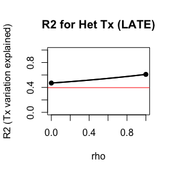

```r
plot( r2 )
```

## The 2SLS Approach

```r
rs = est.beta.LATE( Yobs ~ Z | D,  ~ A + B, data=data, method="2SLS" )
rs
```

```
## RI het tx regression (LATE RI-2SLS):
##  est.beta.LATE(formula = Yobs ~ Z | D, data = data, interaction.formula = ~A +
##      B, method = "2SLS")
##
## Coefficients:
## (Intercept)            A            B
##      55.193       -4.683       -8.287
##
## Var-Cor Matrix:
##             (Intercept)          A          B
## (Intercept)   311.91167 -35.163420 -83.113690
## A             -35.16342   4.770043   8.402705
## B             -83.11369   8.402705  23.401064
##
## Chi-squared test for systematic variation: X^2=4.60 ; p=0.100
```

```r
SE( rs )
```

```
## (Intercept)           A           B
##   17.661021    2.184043    4.837465
```

```r
rs$beta.hat
```

```
## (Intercept)           A           B
##   55.192680   -4.682578   -8.287398
```

```r
rs$beta.hat - beta
```

```
## (Intercept)           A           B
##   56.192680  -10.682578   -8.287398
```